# Gender Prediction Using Body Measurements with Random forest algorithm

Stephen Situ

2022-11-07

This is a project that uses Body Measurement data along with age to predict gender. Using the randomForest algorithm in R, I have created a model with approximately 60% accuracy in the testing data. This model can be refined further by choosing better predictor variables.

The Original data can be found here: https://www.kaggle.com/datasets/saurabhshahane/body-measurements-dataset

The Data has the following properties: Attribute information:

Gender (Male and Female (M=1 & F= 2) (391 Males & 324 Females)

Age (1 year and above)

HeadCircumference (in inches)

ShoulderWidth (in inches)

ChestWidth (in inches)

Belly (in inches)

Waist (in inches)

Hips (in inches)

ArmLength (in inches)

ShoulderToWaist (in inches)

WaistToKnee (in inches)

LegLength (in inches)

TotalHeight - from head to toe (in inches)

Class Label (Not defined)

Dataset Characteristics: Multivariate, Numerical

Attribute Characteristics: Real

Associated Tasks: Classification, Regression

Missing Values: No

Domain: cross domain

# Install Packages

```r
install.packages("tidyverse")
install.packages("randomForest")
install.packages("party")
```

# Load Packages

```r
library(tidyverse)
library(randomForest)
library(party)
```

# Read Csv file

```r
body_measurements <- read.csv("Body Measurements _ original_CSV.csv")
```

# Structure of data

```r
summary(body_measurements)
```

```
##      Gender           Age        HeadCircumference ShoulderWidth
##  Min.   :1.000   Min.   : 1.00   Min.   : 5.00     Min.   : 4.00
##  1st Qu.:1.000   1st Qu.: 7.00   1st Qu.:19.00     1st Qu.:11.00
##  Median :1.000   Median :11.00   Median :20.00     Median :14.00
##  Mean   :1.453   Mean   :15.34   Mean   :20.57     Mean   :14.32
##  3rd Qu.:2.000   3rd Qu.:21.00   3rd Qu.:22.00     3rd Qu.:18.00
##  Max.   :2.000   Max.   :68.00   Max.   :80.00     Max.   :87.00
##  NA's   :1
##    ChestWidth        Belly           Waist            Hips
##  Min.   : 6.00   Min.   :  5.0   Min.   : 2.00   Min.   : 7.00
##  1st Qu.:11.00   1st Qu.: 15.0   1st Qu.:12.00   1st Qu.:12.00
##  Median :13.00   Median : 20.0   Median :20.00   Median :18.00
##  Mean   :14.57   Mean   : 20.2   Mean   :19.27   Mean   :19.38
##  3rd Qu.:17.00   3rd Qu.: 23.0   3rd Qu.:23.00   3rd Qu.:24.00
##  Max.   :38.00   Max.   :213.0   Max.   :91.00   Max.   :63.00
##
##    ArmLength     ShoulderToWaist  WaistToKnee      LegLength
##  Min.   : 6.00   Min.   : 1.0    Min.   : 4.00   Min.   : 9.00
##  1st Qu.:16.00   1st Qu.:13.0    1st Qu.:13.00   1st Qu.:21.00
##  Median :19.00   Median :17.5    Median :16.00   Median :26.00
##  Mean   :18.82   Mean   :17.9    Mean   :16.56   Mean   :26.83
##  3rd Qu.:22.00   3rd Qu.:22.0    3rd Qu.:20.00   3rd Qu.:32.00
##  Max.   :66.00   Max.   :39.0    Max.   :45.00   Max.   :50.00
##
##   TotalHeight
##  Min.   :19.00
##  1st Qu.:40.00
##  Median :48.00
##  Mean   :48.12
##  3rd Qu.:55.00
##  Max.   :89.00
##
```

```r
glimpse(body_measurements)
```

```
## Rows: 716
## Columns: 13
## $ Gender            <int> 1, 1, 2, 1, 2, 2, 2, 2, 1, 1, 1, 1, 2, 1, 2, 2, 2, 1…
## $ Age               <int> 30, 28, 27, 29, 28, 22, 18, 26, 23, 31, 29, 35, 29, …
## $ HeadCircumference <int> 22, 19, 21, 20, 16, 17, 25, 18, 16, 15, 16, 23, 21, …
## $ ShoulderWidth     <int> 18, 22, 18, 20, 14, 19, 17, 15, 16, 20, 28, 21, 19, …
## $ ChestWidth        <int> 20, 17, 16, 18, 18, 18, 16, 19, 20, 28, 17, 18, 17, …
## $ Belly             <int> 18, 18, 14, 11, 13, 14, 17, 17, 18, 18, 15, 12, 17, …
## $ Waist             <int> 14, 21, 10, 19, 11, 16, 12, 23, 22, 91, 21, 18, 20, …
## $ Hips              <int> 22, 25, 15, 14, 30, 18, 28, 27, 18, 17, 30, 27, 21, …
## $ ArmLength         <int> 22, 28, 21, 24, 25, 20, 23, 19, 15, 16, 17, 18, 20, …
## $ ShoulderToWaist   <int> 25, 23, 18, 21, 22, 24, 25, 19, 26, 21, 25, 17, 20, …
## $ WaistToKnee       <int> 25, 25, 14, 20, 32, 21, 14, 19, 20, 21, 18, 19, 18, …
## $ LegLength         <int> 22, 20, 18, 21, 13, 19, 18, 19, 19, 19, 17, 20, 22, …
## $ TotalHeight       <int> 52, 56, 53, 45, 47, 60, 49, 58, 40, 55, 50, 49, 59, …
```

```r
str(body_measurements)
```

```
## 'data.frame':    716 obs. of  13 variables:
##  $ Gender           : int  1 1 2 1 2 2 2 2 1 1 ...
##  $ Age              : int  30 28 27 29 28 22 18 26 23 31 ...
##  $ HeadCircumference: int  22 19 21 20 16 17 25 18 16 15 ...
##  $ ShoulderWidth    : int  18 22 18 20 14 19 17 15 16 20 ...
##  $ ChestWidth       : int  20 17 16 18 18 18 16 19 20 28 ...
##  $ Belly            : int  18 18 14 11 13 14 17 17 18 18 ...
##  $ Waist            : int  14 21 10 19 11 16 12 23 22 91 ...
##  $ Hips             : int  22 25 15 14 30 18 28 27 18 17 ...
##  $ ArmLength        : int  22 28 21 24 25 20 23 19 15 16 ...
##  $ ShoulderToWaist  : int  25 23 18 21 22 24 25 19 26 21 ...
##  $ WaistToKnee      : int  25 25 14 20 32 21 14 19 20 21 ...
##  $ LegLength        : int  22 20 18 21 13 19 18 19 19 19 ...
##  $ TotalHeight      : int  52 56 53 45 47 60 49 58 40 55 ...
```

```r
colnames(body_measurements)
```

```
##  [1] "Gender"            "Age"               "HeadCircumference"
##  [4] "ShoulderWidth"     "ChestWidth"        "Belly"
##  [7] "Waist"             "Hips"              "ArmLength"
## [10] "ShoulderToWaist"   "WaistToKnee"       "LegLength"
## [13] "TotalHeight"
```

# Change Gender data type from int to factor

```r
body_measurements_1 <- mutate(body_measurements, Gender_1 = as.factor(Gender))
body_measurements_2 <- select(body_measurements_1,-1)
```

# View structure of new data frame

```r
summary(body_measurements_2)
```

```
##       Age        HeadCircumference ShoulderWidth     ChestWidth
##  Min.   : 1.00   Min.   : 5.00     Min.   : 4.00   Min.   : 6.00
##  1st Qu.: 7.00   1st Qu.:19.00     1st Qu.:11.00   1st Qu.:11.00
##  Median :11.00   Median :20.00     Median :14.00   Median :13.00
##  Mean   :15.34   Mean   :20.57     Mean   :14.32   Mean   :14.57
##  3rd Qu.:21.00   3rd Qu.:22.00     3rd Qu.:18.00   3rd Qu.:17.00
##  Max.   :68.00   Max.   :80.00     Max.   :87.00   Max.   :38.00
##      Belly           Waist            Hips         ArmLength
##  Min.   :  5.0   Min.   : 2.00   Min.   : 7.00   Min.   : 6.00
##  1st Qu.: 15.0   1st Qu.:12.00   1st Qu.:12.00   1st Qu.:16.00
##  Median : 20.0   Median :20.00   Median :18.00   Median :19.00
##  Mean   : 20.2   Mean   :19.27   Mean   :19.38   Mean   :18.82
##  3rd Qu.: 23.0   3rd Qu.:23.00   3rd Qu.:24.00   3rd Qu.:22.00
##  Max.   :213.0   Max.   :91.00   Max.   :63.00   Max.   :66.00
##  ShoulderToWaist  WaistToKnee      LegLength      TotalHeight    Gender_1
##  Min.   : 1.0    Min.   : 4.00   Min.   : 9.00   Min.   :19.00   1   :391
##  1st Qu.:13.0    1st Qu.:13.00   1st Qu.:21.00   1st Qu.:40.00   2   :324
##  Median :17.5    Median :16.00   Median :26.00   Median :48.00   NA's:  1
##  Mean   :17.9    Mean   :16.56   Mean   :26.83   Mean   :48.12
##  3rd Qu.:22.0    3rd Qu.:20.00   3rd Qu.:32.00   3rd Qu.:55.00
##  Max.   :39.0    Max.   :45.00   Max.   :50.00   Max.   :89.00
```

# Remove Row with N/A (Null) in Gender_1

```r
body_measurements_3 <- body_measurements_2 %>% na.omit()
```

# View structure of new data frame

```r
summary(body_measurements_3)
```

```
##       Age        HeadCircumference ShoulderWidth     ChestWidth
##  Min.   : 1.00   Min.   : 5.00     Min.   : 4.00   Min.   : 6.00
##  1st Qu.: 7.00   1st Qu.:19.00     1st Qu.:11.00   1st Qu.:11.00
##  Median :11.00   Median :20.00     Median :14.00   Median :13.00
##  Mean   :15.35   Mean   :20.57     Mean   :14.32   Mean   :14.57
##  3rd Qu.:21.00   3rd Qu.:22.00     3rd Qu.:18.00   3rd Qu.:17.00
##  Max.   :68.00   Max.   :80.00     Max.   :87.00   Max.   :38.00
##      Belly           Waist            Hips         ArmLength
##  Min.   :  5.0   Min.   : 2.00   Min.   : 7.00   Min.   : 6.00
##  1st Qu.: 15.0   1st Qu.:12.00   1st Qu.:12.00   1st Qu.:16.00
##  Median : 20.0   Median :20.00   Median :18.00   Median :19.00
##  Mean   : 20.2   Mean   :19.26   Mean   :19.39   Mean   :18.81
##  3rd Qu.: 23.0   3rd Qu.:23.00   3rd Qu.:24.00   3rd Qu.:22.00
##  Max.   :213.0   Max.   :91.00   Max.   :63.00   Max.   :66.00
##  ShoulderToWaist  WaistToKnee      LegLength      TotalHeight    Gender_1
##  Min.   : 1.00   Min.   : 4.00   Min.   : 9.00   Min.   :19.00   1:391
##  1st Qu.:13.00   1st Qu.:13.00   1st Qu.:21.00   1st Qu.:40.00   2:324
##  Median :18.00   Median :16.00   Median :26.00   Median :48.00
##  Mean   :17.91   Mean   :16.56   Mean   :26.84   Mean   :48.12
##  3rd Qu.:22.00   3rd Qu.:20.00   3rd Qu.:32.00   3rd Qu.:55.00
##  Max.   :39.00   Max.   :45.00   Max.   :50.00   Max.   :89.00
```

# Set seed for code reproduction

```r
set.seed(49879)
```

# Split the Data into training and testing sets

```r
index <- sample(2,nrow(body_measurements_3),replace = TRUE, prob=c(0.7,0.3))
```

# Assign Training Data set

```r
Training <- body_measurements_3[index==1,]
```

# Assign Testing Data set

```r
Testing <- body_measurements_3[index==2,]
```

# Random Forest Model

```r
RFM <- randomForest(Gender_1~.,data=Training)
```

# Evaluate accuracy with predict function

```r
Prediction <- predict(RFM,Testing)
Testing$Gender_pred = Prediction
```

# Build a confusion matrix, our model gives around 60% accuracy

```r
CFM <- table(Testing$Gender_1,Testing$Gender_pred)
CFM
```

```
##
##      1  2
##   1 78 39
##   2 54 54
```

# Plot a diagram of random trees

# Greatest Predictors are Age followed by Belly and Chest, then followed by Waist To Knee

# Model Could be refined further by changing predictor variables

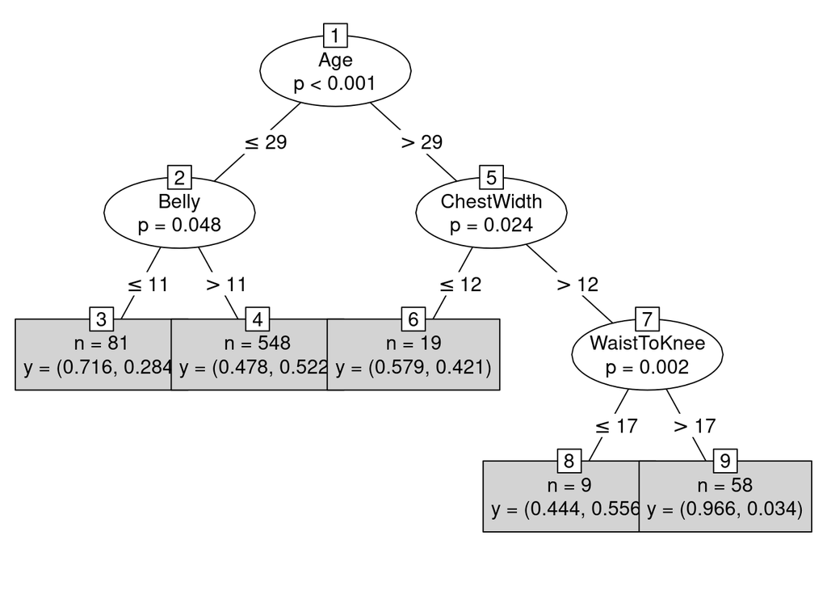

```r
trees <- ctree(Gender_1 ~ ., data=body_measurements_3)
plot(trees, type="simple")
```